# Spotify Recommendations

### Goal is to recommend songs

```python
import pandas as pd
import numpy as np

import matplotlib.pyplot as plt
```

```python
data = pd.read_csv('D:\Python Project\Spotify Dataset\spotify\dataset.csv')
data.head()
```

|  | Unnamed: 0 | track_id | artists | album_name | track_name | popularity | duration_ms | explicit | danceability | energy | ... | loudness | mode | speechiness | acousticness | instrumentalness | liveness | valence | tempo | time_signature | track_genre |
| --- | --- | --- | --- | --- | --- | --- | --- | --- | --- | --- | --- | --- | --- | --- | --- | --- | --- | --- | --- | --- | --- |
| 0 | 0 | 5SuOikwiRyPMVoIQDJUgSV | Gen Hoshino | Comedy | Comedy | 73 | 230666 | False | 0.676 | 0.4610 | ... | -6.746 | 0 | 0.1430 | 0.0322 | 0.000001 | 0.3580 | 0.715 | 87.917 | 4 | acoustic |
| 1 | 1 | 4qPNDBW1i3p13qLCt0Ki3A | Ben Woodward | Ghost (Acoustic) | Ghost - Acoustic | 55 | 149610 | False | 0.420 | 0.1660 | ... | -17.235 | 1 | 0.0763 | 0.9240 | 0.000006 | 0.1010 | 0.267 | 77.489 | 4 | acoustic |
| 2 | 2 | 1iJBSr7s7jYXzM8EGcbK5b | Ingrid Michaelson;ZAYN | To Begin Again | To Begin Again | 57 | 210826 | False | 0.438 | 0.3590 | ... | -9.734 | 1 | 0.0557 | 0.2100 | 0.000000 | 0.1170 | 0.120 | 76.332 | 4 | acoustic |
| 3 | 3 | 6lfxq3CG4xtTiEg7opyCyx | Kina Grannis | Crazy Rich Asians (Original Motion Picture Sou... | Can't Help Falling In Love | 71 | 201933 | False | 0.266 | 0.0596 | ... | -18.515 | 1 | 0.0363 | 0.9050 | 0.000071 | 0.1320 | 0.143 | 181.740 | 3 | acoustic |
| 4 | 4 | 5vjLSffimiIP26QG5WcN2K | Chord Overstreet | Hold On | Hold On | 82 | 198853 | False | 0.618 | 0.4430 | ... | -9.681 | 1 | 0.0526 | 0.4690 | 0.000000 | 0.0829 | 0.167 | 119.949 | 4 | acoustic |

5 rows × 21 columns

### EDA

```python
data.info()
```

```
<class 'pandas.core.frame.DataFrame'>
RangeIndex: 114000 entries, 0 to 113999
Data columns (total 21 columns):
 #   Column            Non-Null Count   Dtype
---  ------            --------------   -----
 0   Unnamed: 0        114000 non-null  int64
 1   track_id          114000 non-null  object
 2   artists           113999 non-null  object
 3   album_name        113999 non-null  object
 4   track_name        113999 non-null  object
 5   popularity        114000 non-null  int64
 6   duration_ms       114000 non-null  int64
 7   explicit          114000 non-null  bool
 8   danceability      114000 non-null  float64
 9   energy            114000 non-null  float64
 10  key               114000 non-null  int64
 11  loudness          114000 non-null  float64
 12  mode              114000 non-null  int64
 13  speechiness       114000 non-null  float64
 14  acousticness      114000 non-null  float64
 15  instrumentalness  114000 non-null  float64
 16  liveness          114000 non-null  float64
 17  valence           114000 non-null  float64
 18  tempo             114000 non-null  float64
 19  time_signature    114000 non-null  int64
 20  track_genre       114000 non-null  object
dtypes: bool(1), float64(9), int64(6), object(5)
memory usage: 17.5+ MB
```

```python
data['track_genre'].value_counts(ascending=False)
```

```
track_genre
acoustic             1000
punk-rock            1000
progressive-house    1000
power-pop            1000
pop                  1000
                     ...
folk                 1000
emo                  1000
electronic           1000
electro              1000
world-music          1000
Name: count, Length: 114, dtype: int64
```

```python
data['track_genre'].nunique()
```

```
114
```

```python
len(data[data['track_genre'] == 'hip-hop'])
```

```
1000
```

```python
data.shape
```

```
(114000, 21)
```

Exploring Popularity

```python
data['popularity'].describe()
```

```
count    114000.000000
mean         33.238535
std          22.305078
min           0.000000
25%          17.000000
50%          35.000000
75%          50.000000
max         100.000000
Name: popularity, dtype: float64
```

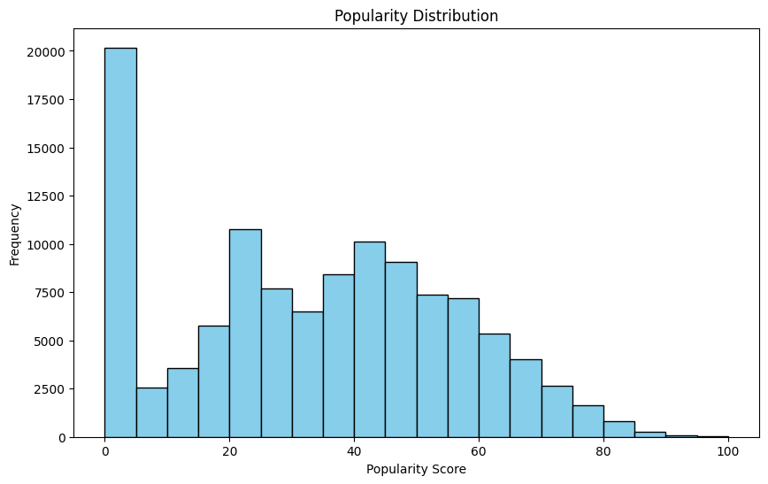

```python
plt.figure(figsize=(10, 6))
plt.hist(data['popularity'], bins=20, color='skyblue', edgecolor='black')
plt.title('Popularity Distribution')
plt.xlabel('Popularity Score')
plt.ylabel('Frequency')
plt.show()
```

Seems to be roughly normally distributed outside of the extremely high frequency of 0. I will make the assumption that if song has a popularity of 0, we will not suggest it to them. Therefore, we can remove songs with the popularity of 0.

```python
data = data[data['popularity'] != 0]
data.shape
```

```
(97980, 21)
```

```python
#Removing Duplicate Songs as many songs on spotify can be found as singles and within an album
data = data.drop_duplicates(subset=['track_name', 'artists'])
data.shape
```

```
(76585, 21)
```

```python
#I need to reduce the size of this dataset for my computer due to low RAM
#data = data.sample(n=10000).reset_index(drop=True)
```

```python
#Finding Some songs I want suggestions of.

data[data['artists'] == "Arctic Monkeys"].head()
```

|  | Unnamed: 0 | track_id | artists | album_name | track_name | popularity | duration_ms | explicit | danceability | energy | ... | loudness | mode | speechiness | acousticness | instrumentalness | liveness | valence | tempo | time_signature | track_genre |
| --- | --- | --- | --- | --- | --- | --- | --- | --- | --- | --- | --- | --- | --- | --- | --- | --- | --- | --- | --- | --- | --- |
| 38000 | 38000 | 5XeFesFbtLpXzIVDNQP22n | Arctic Monkeys | AM | I Wanna Be Yours | 92 | 183956 | False | 0.464 | 0.417 | ... | -9.345 | 0 | 0.0256 | 0.13600 | 0.022000 | 0.0974 | 0.479 | 67.528 | 4 | garage |
| 38001 | 38001 | 5FVd6KXrgO9B3JPmC8OPst | Arctic Monkeys | AM | Do I Wanna Know? | 88 | 272394 | False | 0.548 | 0.532 | ... | -7.596 | 1 | 0.0323 | 0.18600 | 0.000263 | 0.2170 | 0.405 | 85.030 | 4 | garage |
| 38003 | 38003 | 0BxE4FqsDD1Ot4YuBXwAPp | Arctic Monkeys | Favourite Worst Nightmare | 505 | 88 | 253586 | False | 0.526 | 0.866 | ... | -5.822 | 1 | 0.0568 | 0.00287 | 0.000078 | 0.0945 | 0.248 | 140.266 | 4 | garage |
| 38004 | 38004 | 086myS9r57YsLbJpU0TgK9 | Arctic Monkeys | AM | Why'd You Only Call Me When You're High? | 88 | 161123 | False | 0.691 | 0.631 | ... | -6.478 | 1 | 0.0368 | 0.04830 | 0.000011 | 0.1040 | 0.800 | 92.004 | 4 | garage |
| 38006 | 38006 | 2AT8iROs4FQueDv2c8q2KE | Arctic Monkeys | AM | R U Mine? | 83 | 201726 | False | 0.288 | 0.758 | ... | -5.692 | 0 | 0.0371 | 0.00616 | 0.000000 | 0.3030 | 0.619 | 97.094 | 4 | garage |

5 rows × 21 columns

Check the histogram of popularity once again.

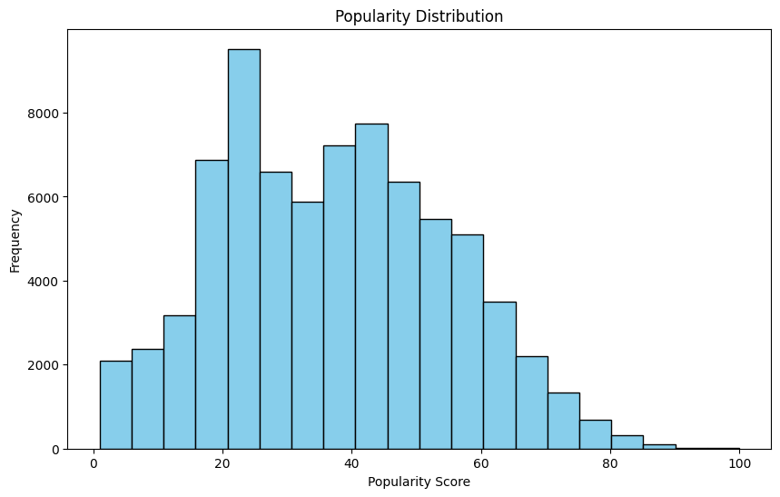

```python
plt.figure(figsize=(10, 6))
plt.hist(data['popularity'], bins=20, color='skyblue', edgecolor='black')
plt.title('Popularity Distribution')
plt.xlabel('Popularity Score')
plt.ylabel('Frequency')
plt.show()
```

We can continue to delete irrelevant columns such as the unnamed column and the spotify id column. We will use the index to reference the data later.

```python
data = data.drop(['Unnamed: 0', "track_id"], axis= 1)
data.head()
```

|  | artists | album_name | track_name | popularity | duration_ms | explicit | danceability | energy | key | loudness | mode | speechiness | acousticness | instrumentalness | liveness | valence | tempo | time_signature | track_genre |
| --- | --- | --- | --- | --- | --- | --- | --- | --- | --- | --- | --- | --- | --- | --- | --- | --- | --- | --- | --- |
| 0 | Gen Hoshino | Comedy | Comedy | 73 | 230666 | False | 0.676 | 0.4610 | 1 | -6.746 | 0 | 0.1430 | 0.0322 | 0.000001 | 0.3580 | 0.715 | 87.917 | 4 | acoustic |
| 1 | Ben Woodward | Ghost (Acoustic) | Ghost - Acoustic | 55 | 149610 | False | 0.420 | 0.1660 | 1 | -17.235 | 1 | 0.0763 | 0.9240 | 0.000006 | 0.1010 | 0.267 | 77.489 | 4 | acoustic |
| 2 | Ingrid Michaelson;ZAYN | To Begin Again | To Begin Again | 57 | 210826 | False | 0.438 | 0.3590 | 0 | -9.734 | 1 | 0.0557 | 0.2100 | 0.000000 | 0.1170 | 0.120 | 76.332 | 4 | acoustic |
| 3 | Kina Grannis | Crazy Rich Asians (Original Motion Picture Sou... | Can't Help Falling In Love | 71 | 201933 | False | 0.266 | 0.0596 | 0 | -18.515 | 1 | 0.0363 | 0.9050 | 0.000071 | 0.1320 | 0.143 | 181.740 | 3 | acoustic |
| 4 | Chord Overstreet | Hold On | Hold On | 82 | 198853 | False | 0.618 | 0.4430 | 2 | -9.681 | 1 | 0.0526 | 0.4690 | 0.000000 | 0.0829 | 0.167 | 119.949 | 4 | acoustic |

I want to include the genre category in recommendation so I will use the TFidf Vectorizer function on the string text

```python
from sklearn.feature_extraction.text import TfidfVectorizer
from sklearn.preprocessing import StandardScaler
from sklearn.metrics.pairwise import cosine_similarity
```

```python
data['track_genre'] = data['track_genre'].fillna("")
tfidf_vector = TfidfVectorizer(stop_words='english', min_df= 100, max_features= 30)
tfidf_matrix_genre = tfidf_vector.fit_transform(data['track_genre'])
tfidf_matrix_genre
```

```
<76585x30 sparse matrix of type '<class 'numpy.float64'>'
	with 40230 stored elements in Compressed Sparse Row format>
```

```python
type(tfidf_matrix_genre)
```

```
scipy.sparse._csr.csr_matrix
```

Next, I will Scale the rest of my numeric data

```python
data.columns
```

```
Index(['artists', 'album_name', 'track_name', 'popularity', 'duration_ms',
       'explicit', 'danceability', 'energy', 'key', 'loudness', 'mode',
       'speechiness', 'acousticness', 'instrumentalness', 'liveness',
       'valence', 'tempo', 'time_signature', 'track_genre'],
      dtype='object')
```

```python
selected_features = data[['popularity', 'duration_ms',
       'explicit', 'danceability', 'energy', 'key', 'loudness', 'mode',
       'speechiness', 'acousticness', 'instrumentalness', 'liveness',
       'valence', 'tempo', 'time_signature']]

#Explicit is also a string so I can quickly dummy that variable
selected_features['explicit'] = selected_features['explicit'].astype(int)
selected_features
```

[output not shown]

|  | popularity | duration_ms | explicit | danceability | energy | key | loudness | mode | speechiness | acousticness | instrumentalness | liveness | valence | tempo | time_signature |
| --- | --- | --- | --- | --- | --- | --- | --- | --- | --- | --- | --- | --- | --- | --- | --- |
| 0 | 73 | 230666 | 0 | 0.676 | 0.4610 | 1 | -6.746 | 0 | 0.1430 | 0.0322 | 0.000001 | 0.3580 | 0.7150 | 87.917 | 4 |
| 1 | 55 | 149610 | 0 | 0.420 | 0.1660 | 1 | -17.235 | 1 | 0.0763 | 0.9240 | 0.000006 | 0.1010 | 0.2670 | 77.489 | 4 |
| 2 | 57 | 210826 | 0 | 0.438 | 0.3590 | 0 | -9.734 | 1 | 0.0557 | 0.2100 | 0.000000 | 0.1170 | 0.1200 | 76.332 | 4 |
| 3 | 71 | 201933 | 0 | 0.266 | 0.0596 | 0 | -18.515 | 1 | 0.0363 | 0.9050 | 0.000071 | 0.1320 | 0.1430 | 181.740 | 3 |
| 4 | 82 | 198853 | 0 | 0.618 | 0.4430 | 2 | -9.681 | 1 | 0.0526 | 0.4690 | 0.000000 | 0.0829 | 0.1670 | 119.949 | 4 |
| ... | ... | ... | ... | ... | ... | ... | ... | ... | ... | ... | ... | ... | ... | ... | ... |
| 113995 | 21 | 384999 | 0 | 0.172 | 0.2350 | 5 | -16.393 | 1 | 0.0422 | 0.6400 | 0.928000 | 0.0863 | 0.0339 | 125.995 | 5 |
| 113996 | 22 | 385000 | 0 | 0.174 | 0.1170 | 0 | -18.318 | 0 | 0.0401 | 0.9940 | 0.976000 | 0.1050 | 0.0350 | 85.239 | 4 |
| 113997 | 22 | 271466 | 0 | 0.629 | 0.3290 | 0 | -10.895 | 0 | 0.0420 | 0.8670 | 0.000000 | 0.0839 | 0.7430 | 132.378 | 4 |
| 113998 | 41 | 283893 | 0 | 0.587 | 0.5060 | 7 | -10.889 | 1 | 0.0297 | 0.3810 | 0.000000 | 0.2700 | 0.4130 | 135.960 | 4 |
| 113999 | 22 | 241826 | 0 | 0.526 | 0.4870 | 1 | -10.204 | 0 | 0.0725 | 0.6810 | 0.000000 | 0.0893 | 0.7080 | 79.198 | 4 |

76585 rows × 15 columns

```python
#Scaling Features
scaler = StandardScaler()
scaled_selected_numeric = scaler.fit_transform(selected_features)
```

```python
type(scaled_selected_numeric)
```

```
numpy.ndarray
```

```python
#Combining the numeric features with the genre data

#making a columns variable
scaled_columns = ['popularity', 'duration_ms',
       'explicit', 'danceability', 'energy', 'key', 'loudness', 'mode',
       'speechiness', 'acousticness', 'instrumentalness', 'liveness',
       'valence', 'tempo', 'time_signature']

combined_matrix = pd.concat([pd.DataFrame(scaled_selected_numeric, columns = scaled_columns),
                             pd.DataFrame(tfidf_matrix_genre.toarray(), columns = tfidf_vector.get_feature_names_out())],
                             axis= 1)
```

```python
combined_matrix.columns[15:]
```

```
Index(['acoustic', 'afrobeat', 'age', 'anime', 'black', 'bluegrass',
       'breakbeat', 'cantopop', 'chicago', 'club', 'comedy', 'dance',
       'detroit', 'disney', 'drum', 'forro', 'grindcore', 'heavy', 'hop',
       'house', 'idm', 'kids', 'malay', 'metal', 'new', 'pop', 'rock', 'study',
       'tango', 'techno'],
      dtype='object')
```

```python
combined_matrix.iloc[:, 15:].sum().sort_values(ascending=False)
```

```
pop          4399.000000
rock         3699.000000
metal        2297.713010
house        2224.610432
techno       1800.321268
hop          1451.000000
dance        1097.000000
comedy        987.000000
study         983.000000
bluegrass     972.000000
forro         968.000000
malay         964.000000
grindcore     962.000000
breakbeat     953.000000
idm           947.000000
disney        947.000000
club          945.000000
afrobeat      945.000000
cantopop      943.000000
anime         935.000000
kids          927.000000
tango         921.000000
acoustic      916.000000
drum          915.000000
black         775.440858
heavy         772.525934
chicago       737.813586
detroit       701.805438
new           658.316413
age           658.316413
dtype: float64
```

```python
combined_matrix
```

|  | popularity | duration_ms | explicit | danceability | energy | key | loudness | mode | speechiness | acousticness | ... | idm | kids | malay | metal | new | pop | rock | study | tango | techno |
| --- | --- | --- | --- | --- | --- | --- | --- | --- | --- | --- | --- | --- | --- | --- | --- | --- | --- | --- | --- | --- | --- |
| 0 | 2.011123 | -0.007229 | -0.307652 | 0.648940 | -0.702377 | -1.204961 | 0.337091 | -1.313820 | 0.450384 | -0.866564 | ... | 0.0 | 0.0 | 0.0 | 0.0 | 0.0 | 0.0 | 0.0 | 0.0 | 0.0 | 0.0 |
| 1 | 1.002107 | -0.702171 | -0.307652 | -0.804441 | -1.858001 | -1.204961 | -1.685047 | 0.761139 | -0.112822 | 1.792773 | ... | 0.0 | 0.0 | 0.0 | 0.0 | 0.0 | 0.0 | 0.0 | 0.0 | 0.0 | 0.0 |
| 2 | 1.114220 | -0.177329 | -0.307652 | -0.702250 | -1.101949 | -1.486017 | -0.238955 | 0.761139 | -0.286765 | -0.336367 | ... | 0.0 | 0.0 | 0.0 | 0.0 | 0.0 | 0.0 | 0.0 | 0.0 | 0.0 | 0.0 |
| 3 | 1.899010 | -0.253574 | -0.307652 | -1.678740 | -2.274809 | -1.486017 | -1.931814 | 0.761139 | -0.450576 | 1.736115 | ... | 0.0 | 0.0 | 0.0 | 0.0 | 0.0 | 0.0 | 0.0 | 0.0 | 0.0 | 0.0 |
| 4 | 2.515631 | -0.279981 | -0.307652 | 0.319658 | -0.772890 | -0.923905 | -0.228737 | 0.761139 | -0.312941 | 0.435968 | ... | 0.0 | 0.0 | 0.0 | 0.0 | 0.0 | 0.0 | 0.0 | 0.0 | 0.0 | 0.0 |
| ... | ... | ... | ... | ... | ... | ... | ... | ... | ... | ... | ... | ... | ... | ... | ... | ... | ... | ... | ... | ... | ... |
| 76580 | -0.903811 | 1.315960 | -0.307652 | -2.212404 | -1.587702 | -0.080737 | -1.522721 | 0.761139 | -0.400757 | 0.945888 | ... | 0.0 | 0.0 | 0.0 | 0.0 | 0.0 | 0.0 | 0.0 | 0.0 | 0.0 | 0.0 |
| 76581 | -0.847755 | 1.315969 | -0.307652 | -2.201049 | -2.049952 | -1.486017 | -1.893835 | -1.313820 | -0.418489 | 2.001512 | ... | 0.0 | 0.0 | 0.0 | 0.0 | 0.0 | 0.0 | 0.0 | 0.0 | 0.0 | 0.0 |
| 76582 | -0.847755 | 0.342574 | -0.307652 | 0.382108 | -1.219470 | -1.486017 | -0.462780 | -1.313820 | -0.402446 | 1.622800 | ... | 0.0 | 0.0 | 0.0 | 0.0 | 0.0 | 0.0 | 0.0 | 0.0 | 0.0 | 0.0 |
| 76583 | 0.217318 | 0.449118 | -0.307652 | 0.143663 | -0.526096 | 0.481375 | -0.461624 | 0.761139 | -0.506306 | 0.173553 | ... | 0.0 | 0.0 | 0.0 | 0.0 | 0.0 | 0.0 | 0.0 | 0.0 | 0.0 | 0.0 |
| 76584 | -0.847755 | 0.088452 | -0.307652 | -0.202650 | -0.600526 | -1.204961 | -0.329565 | -1.313820 | -0.144908 | 1.068150 | ... | 0.0 | 0.0 | 0.0 | 0.0 | 0.0 | 0.0 | 0.0 | 0.0 | 0.0 | 0.0 |

76585 rows × 45 columns

### Building Recommender

The above code helped me think through how I will create the recommender, below I will began creating the model.

```python
#First I will need to combine the TFIDF info will the full data frame
data_full = pd.concat([data, pd.DataFrame(tfidf_matrix_genre.toarray(), columns=tfidf_vector.get_feature_names_out())], axis=1)
data_full.head()
```

|  | artists | album_name | track_name | popularity | duration_ms | explicit | danceability | energy | key | loudness | ... | idm | kids | malay | metal | new | pop | rock | study | tango | techno |
| --- | --- | --- | --- | --- | --- | --- | --- | --- | --- | --- | --- | --- | --- | --- | --- | --- | --- | --- | --- | --- | --- |
| 0 | Gen Hoshino | Comedy | Comedy | 73.0 | 230666.0 | False | 0.676 | 0.4610 | 1.0 | -6.746 | ... | 0.0 | 0.0 | 0.0 | 0.0 | 0.0 | 0.0 | 0.0 | 0.0 | 0.0 | 0.0 |
| 1 | Ben Woodward | Ghost (Acoustic) | Ghost - Acoustic | 55.0 | 149610.0 | False | 0.420 | 0.1660 | 1.0 | -17.235 | ... | 0.0 | 0.0 | 0.0 | 0.0 | 0.0 | 0.0 | 0.0 | 0.0 | 0.0 | 0.0 |
| 2 | Ingrid Michaelson;ZAYN | To Begin Again | To Begin Again | 57.0 | 210826.0 | False | 0.438 | 0.3590 | 0.0 | -9.734 | ... | 0.0 | 0.0 | 0.0 | 0.0 | 0.0 | 0.0 | 0.0 | 0.0 | 0.0 | 0.0 |
| 3 | Kina Grannis | Crazy Rich Asians (Original Motion Picture Sou... | Can't Help Falling In Love | 71.0 | 201933.0 | False | 0.266 | 0.0596 | 0.0 | -18.515 | ... | 0.0 | 0.0 | 0.0 | 0.0 | 0.0 | 0.0 | 0.0 | 0.0 | 0.0 | 0.0 |
| 4 | Chord Overstreet | Hold On | Hold On | 82.0 | 198853.0 | False | 0.618 | 0.4430 | 2.0 | -9.681 | ... | 0.0 | 0.0 | 0.0 | 0.0 | 0.0 | 0.0 | 0.0 | 0.0 | 0.0 | 0.0 |

5 rows × 49 columns

Checking our TFIDF genre categories... Seems to have done the trick in combining similar genres.

```python
data_full.iloc[:, 19:].sum().sort_values(ascending=False)
```

```
pop          4399.000000
rock         3699.000000
metal        2297.713010
house        2224.610432
techno       1800.321268
hop          1451.000000
dance        1097.000000
comedy        987.000000
study         983.000000
bluegrass     972.000000
forro         968.000000
malay         964.000000
grindcore     962.000000
breakbeat     953.000000
idm           947.000000
disney        947.000000
club          945.000000
afrobeat      945.000000
cantopop      943.000000
anime         935.000000
kids          927.000000
tango         921.000000
acoustic      916.000000
drum          915.000000
black         775.440858
heavy         772.525934
chicago       737.813586
detroit       701.805438
new           658.316413
age           658.316413
dtype: float64
```

```python
for i, column_name in enumerate(data_full.columns):
    print(f"{i}, Col Name: {column_name}")
```

```
0, Col Name: artists
1, Col Name: album_name
2, Col Name: track_name
3, Col Name: popularity
4, Col Name: duration_ms
5, Col Name: explicit
6, Col Name: danceability
7, Col Name: energy
8, Col Name: key
9, Col Name: loudness
10, Col Name: mode
11, Col Name: speechiness
12, Col Name: acousticness
13, Col Name: instrumentalness
14, Col Name: liveness
```

[output cut: 34 more lines]

Here we see the engineered genres start in column 19

### Creaing the Function to recommend songs based on our dataframe with TDIDF info.

```python
#hard-coding
#song_title = "Is This It"

num_non_genre_cols = ['popularity', 'duration_ms', 'danceability', 'energy', 'key',
       'loudness', 'mode', 'speechiness', 'acousticness', 'instrumentalness',
       'liveness', 'valence', 'tempo', 'time_signature']

def tfidf_recommender(song_title):
    #First we need to subset the data based on tfidf genre breakdown

    #Finding the Song Genre Characteristics
    song_index = data_full[data_full['track_name'] == song_title].index[0]
    song_genres = data_full.loc[song_index][19:].sort_values(ascending = False)
    genre_list = [i for i in song_genres.index if song_genres.loc[i] > 0]
    subset_data = data_full[data_full.loc[:, genre_list].sum(axis=1) > 0]
    subset_data = subset_data.reset_index(drop=True)
    subset_data = subset_data[subset_data['track_name'].notna()]


    #Only Considering numeric values of subset
    numeric = subset_data.select_dtypes(include="number")
    #I also need to no longer include the genre related categories in the numeric df
    numeric = numeric[num_non_genre_cols]


    #Scaling Subset
    numeric_scaled = scaler.fit_transform(numeric)

    #Creating Similarity Matrix
    cos_sim = cosine_similarity(numeric_scaled, numeric_scaled)
    #locating song index
    song_index = subset_data[subset_data['track_name'] == song_title].index[0]
    #Gathering similarity scores
    sim_scores = list(enumerate(cos_sim[song_index]))
    #Sorting Similarity scores
    sim_scores = sorted(sim_scores, key=lambda x: x[1], reverse=True)
    top_similar_indices = [i[0] for i in sim_scores[1:11]]  # Exclude the input song itself

    recommendations = subset_data.loc[top_similar_indices, ['track_name', 'artists']]
    #Adding Similarity score to df
    recommendations['Similarity Score'] = [i[1] for i in sim_scores[1:11]]
    recommendations = recommendations[['track_name', "artists", "Similarity Score"]]

    return recommendations
```

```python
tfidf_recommender("Is This It")
```

|  | track_name | artists | Similarity Score |
| --- | --- | --- | --- |
| 931 | Valerie - Glee Cast Version | Glee Cast | 0.897481 |
| 971 | Tiro | Arca | 0.874966 |
| 2042 | Science Fiction | Arctic Monkeys | 0.862095 |
| 1438 | Last Christmas | Glee Cast | 0.858577 |
| 544 | ParadoXXX Invasion | ENHYPEN | 0.855894 |
| 1365 | Raise Your Glass (feat. Darren Criss) | Glee Cast;Darren Criss | 0.852853 |
| 1817 | Someday | The Strokes | 0.843488 |
| 1759 | Figa de Guiné | Mc Tha;Comunidade Jongo Dito Ribeiro | 0.833964 |
| 533 | Make the change | ENHYPEN | 0.832063 |
| 684 | Canzoni preferite | Yugo Kanno | 0.825449 |

### I want to make the recommender more specific, only recommending songs within the exact same genre

Here we will no longer need to use tfidf to convert genre text into integers

```python
#hard-coding song title
#song_title = "Is This It"

def genre_recommend(song_title):
    #Finding the song genre
    song_genre = data[data['track_name'] == song_title]['track_genre'].iloc[0]

    #Filtering the data based on genre
    data_subset = data[data['track_genre'] == song_genre]
    #Resetting the index
    data_subset = data_subset.reset_index(drop=True)

    #Only Considering numeric values of subset
    numeric = data_subset.select_dtypes(include="number")

    #Scaling Subset
    numeric_scaled = scaler.fit_transform(numeric)

    #Creating Similarity Matrix
    cos_sim = cosine_similarity(numeric_scaled, numeric_scaled)
    #locating song index
    song_index = data_subset[data_subset['track_name'] == song_title].index[0]
    #Gathering similarity scores
    sim_scores = list(enumerate(cos_sim[song_index]))
    #Sorting Similarity scores
    sim_scores = sorted(sim_scores, key=lambda x: x[1], reverse=True)
    top_similar_indices = [i[0] for i in sim_scores[1:11]]  # Exclude the input song itself

    recommendations = data_subset.loc[top_similar_indices, ['track_name', 'artists']]
    #Adding Similarity score to df
    recommendations['Similarity Score'] = [i[1] for i in sim_scores[1:11]]
    recommendations = recommendations[['track_name', "artists", "Similarity Score"]]

    return recommendations
```

```python
genre_recommend("Is This It")
```

|  | track_name | artists | Similarity Score |
| --- | --- | --- | --- |
| 587 | Something New | Babe Rainbow | 0.790234 |
| 41 | Someday | The Strokes | 0.779021 |
| 3 | Why'd You Only Call Me When You're High? | Arctic Monkeys | 0.778501 |
| 435 | Shy | Hether | 0.772509 |
| 223 | Black Memories | The Growlers | 0.753455 |
| 266 | Science Fiction | Arctic Monkeys | 0.739707 |
| 98 | $10 | Good Morning | 0.713811 |
| 628 | Surfin' Bird | The Trashmen | 0.707717 |
| 4 | Homage | Mild High Club | 0.705577 |
| 718 | Suddenly | Drugdealer;Weyes Blood | 0.704653 |

It seems the first recommender system worked the best based on similarity score. Although, anecdotally the specifc genre based version seems to be a better fit based on my knowledge of music.

### Creating a Widget for the Recommendations

Currently, we get some interesting suggestions for similar songs but it is a little tough to use as you have to input the precise song name and many song names may have different artists. To counteract that I will make a search widget within Python.